# Praca domowa 2

Katarzyna Skoczylas

## Dane

Dane wykorzystane w Pracy domowej 2 opisują wycenę nieruchmości. Każda obserwacja jest pewną nieruchmością, która posiada informacje takie jak powierzchnia, liczba pokoi, liczba łazienek i wiele więcj. Opis wszystkich kolumn w pliku `README.md`.

## Zadanie 1

Jak wygląda rozkład ceny nieruchomości w poszczególnych kodach pocztowych na przestrzeni lat? Rozważamy kody pocztowe, które mają więcej niż 280 posiadłości.

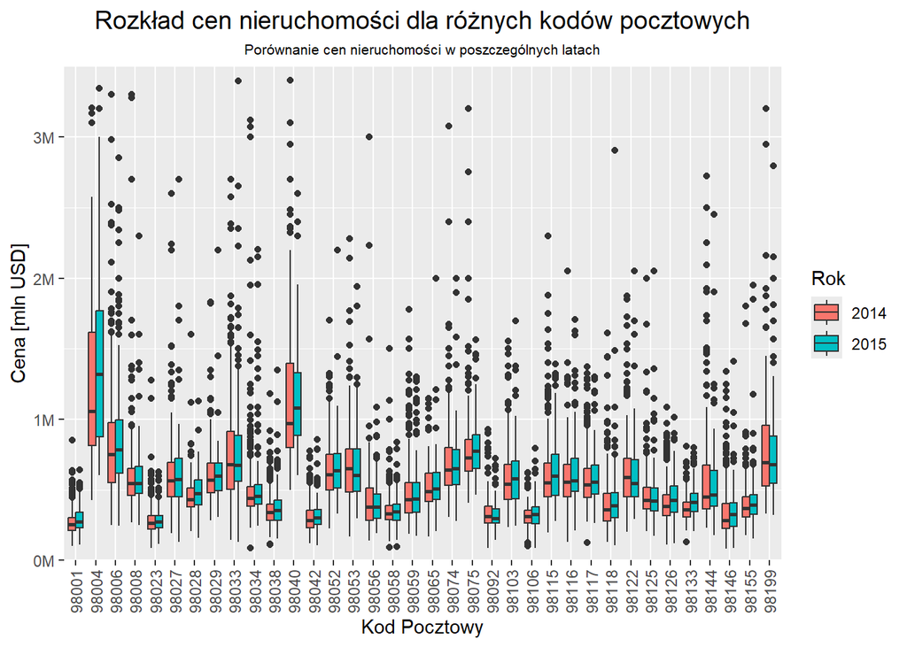

```r
# Tu umieść kod do wygenerowania odpowiedzi do zadania.
kody_pocztowe <- df %>%
  group_by(zipcode) %>%
  summarise(count = n()) %>%
  filter(count > 280)

df_1 <- df %>%
  filter(zipcode %in% kody_pocztowe$zipcode) %>%
  mutate(year = as.numeric(stringr::str_sub(date,1,4))) %>%
  select(year, zipcode, price) %>%
  ggplot(aes(y = price, x = as.factor(zipcode), fill = as.factor(year))) +
  geom_boxplot(position = position_dodge(width = 0.75)) +
  scale_x_discrete(guide = guide_axis(angle = 90))+
  scale_y_continuous(expand = c(0,0),
                     limits = c(0, 3500000),
                     labels = scales::label_number(scale = 1e-6, suffix = "M")
                     ) +
 labs(
   title = "Rozkład cen nieruchomości dla różnych kodów pocztowych",
   subtitle = "Porównanie cen nieruchomości w poszczególnych latach",
   x = "Kod Pocztowy",
   y = "Cena [mln USD]",
   fill = "Rok") +
theme(plot.title = element_text(hjust = 0.5, size = 14),
      plot.subtitle = element_text(hjust = 0.5, size = 8))
df_1
```

**Komentarz:** W latach 2014 i 2015 ceny utrzymywały się na podobym poziomie, mediana cen nieruchomości dla poszczególnych kodów pocztowych nie zmieniała się znacząco. Można zauważyć zarówno niewielkie wzrosty, jak i spadki. Dla nieznacznie większej części kodów cena była odrobinę wyższa w 2015 roku. Patrząc na wszystkie kody pocztowe, ceny nieruchomości wyróżniają się znacząco tylko w kilku przypadkach, np. kody 98004 lub 98040 mają zdecydowanie wyższe ceny, natomiast kody 98023, 98042, 98092 i 98106 najniższe. Wybrałam typ wykresu boxplot i aby był on bardziej czytelny zmniejszyłam limit na osi y, tracąc przy tym 13 outlinerów.

## Zadanie 2

Czy jest różnica w rozkładzie ceny nierchomości od powierzchni mieszkalnej uwzględniając podział na nieruchomości z piwnicą i bez?

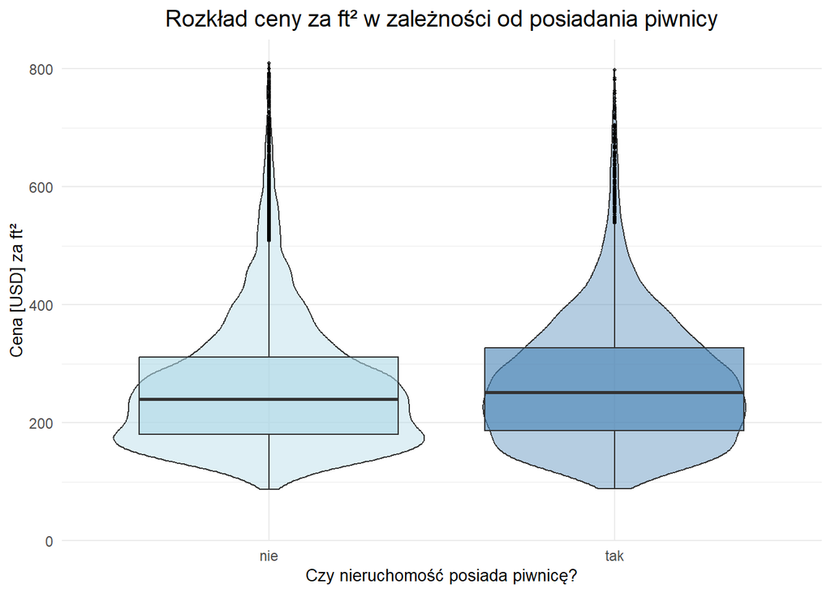

```r
# Tu umieść kod do wygenerowania odpowiedzi do zadania.

df_2 <- df %>%
  mutate(price_sqft = price / sqft_living,
         basement =
           case_when(
             sqft_basement > 0 ~ "tak",
             sqft_basement == 0 ~ "nie"
           )) %>%
  ggplot(aes(x = basement, y = price_sqft, fill = as.factor(basement))) +
  geom_violin(alpha = 0.4) +
  geom_boxplot(outlier.colour = "black", outlier.size = 0.8, alpha = 0.6) +
 labs(
   title = "Rozkład ceny za ft² w zależności od posiadania piwnicy",
   x = "Czy nieruchomość posiada piwnicę?",
   y = "Cena [USD] za ft²",
   ) +
  theme_minimal()+
theme(
    plot.title = element_text(hjust = 0.5, size = 14),
    axis.title.x = element_text(size = 10),
    axis.title.y = element_text(size = 10),
    legend.position = "none"
  ) +
  scale_y_continuous(expand = c(0,0), limits = c(0,850)) +
  scale_fill_manual(values = c("tak" = "steelblue", "nie" = "lightblue"))
df_2
```

**Komentarz:** Cena za 1 ft² nieruchomości z piwnicą jest lekko wyższa od ceny za 1 ft² nieruchomości bez piwnicy. Dla nieruchomości bez piwnicy w violinplocie mamy większe zagęszczenie dla tańszych nieruchomości. Mediana jest większa dla nieruchomości z piwnicą. Najlepszym pomysłem na wizualizację, która pozwoliłaby odpowiedzieć na pytanie wydawało mi policzenie ceny za 1 ft². Dodatkowo, żeby lepiej zauważyć różnice w rozkładzie użyłam zarówno violin, jak i boxplotu.

## Zadanie 3

Jaka jest zależność pomiędzy jakością wykończenia nieruchomości a liczbą pięter?

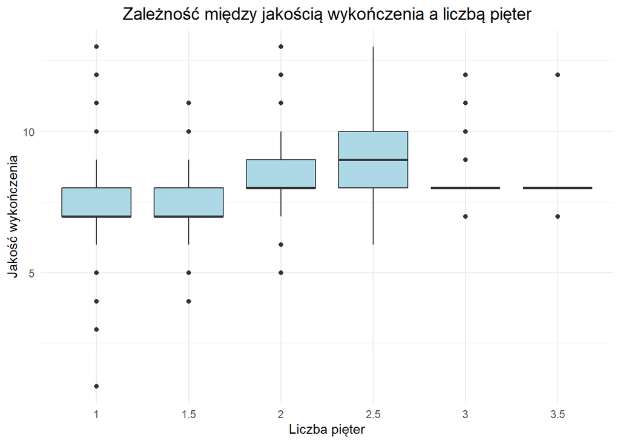

```r
# Tu umieść kod do wygenerowania odpowiedzi do zadania.

df_3 <- ggplot(df, aes(x = as.factor(floors), y = grade)) +
  geom_boxplot(fill = "lightblue") +
  labs(title = "Zależność między jakością wykończenia a liczbą pięter",
       x = "Liczba pięter",
       y = "Jakość wykończenia") +
  theme_minimal()+
  theme(plot.title = element_text(hjust = 0.5, size = 14))

df_3
```

**Komentarz:** Dla 2.5 pięter mediana jakości wykończenia jest największa i wynosi 9. Najmniejsza mediana przyjmowana jest dla 1 i 1.5 pięter, wynosi 7. Natomiast dla pozostałej liczby pięter wynosi ona 8. Stąd wniosek, że do liczby pięter równej 2.5 mediana rośnie. Wykres typu boxplot w czytelny sposób pokazuje, że najlepiej oceniane są nieruchomości z 2.5 piętrami.

## Zadanie 4

Jaka jest zależność między powierzchnią mieszkalną nieruchomości a powierzchnią gruntu w podziale na liczbę sypialni?

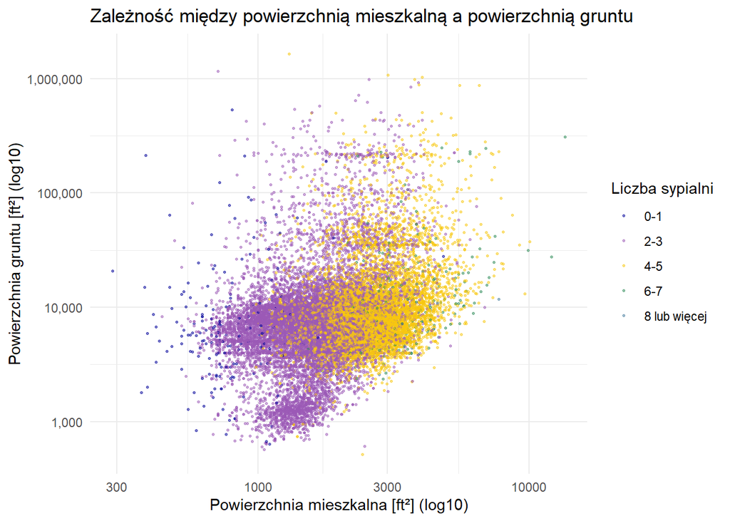

```r
# Tu umieść kod do wygenerowania odpowiedzi do zadania.

df_4 <- df %>%
  mutate(bedrooms_grouped = case_when(
    bedrooms < 2 ~ "0-1",
    bedrooms < 4 & bedrooms >=2 ~ "2-3",
    bedrooms < 6 & bedrooms >=4 ~ "4-5",
    bedrooms < 8 & bedrooms >=6 ~ "6-7",
    bedrooms >= 8 ~ "8 lub więcej"),
    bedrooms_grouped = factor(bedrooms_grouped,
                                    levels = c("0-1", "2-3", "4-5", "6-7", "8 lub więcej")))

df_4_1 <- ggplot(df_4, aes(x = sqft_living, y = sqft_lot, color = bedrooms_grouped)) +
  geom_point(alpha = 0.5, size = 0.5) +
  scale_x_log10() +
  scale_y_continuous(trans = 'log10', labels = scales::comma_format()) +
  scale_color_manual(values = c("0-1" = "#000099",
                   "2-3" = "#9B59B6",
                   "4-5" = "#F8C70E",
                   "6-7" = "#2E8B57",
                   "8 lub więcej" = "#457B9D")) +
  labs(
    title = "Zależność między powierzchnią mieszkalną a powierzchnią gruntu",
    x = "Powierzchnia mieszkalna [ft²] (log10)",
    y = "Powierzchnia gruntu [ft²] (log10)",
    color = "Liczba sypialni"
  ) +
  theme_minimal()

df_4_1
```

**Komentarz:** Czym większa powierzchnia mieszkalna, tym większa powierzchnia gruntu. Dodatkowo ze wzrostem powierzchni mieszkalnej i gruntu wzrasta liczba sypialni. Najwięcej nieruchomości posiada od 2 do 5 sypialni i to one są najbardziej zauważalne na wykresie. Pogrupowałam liczbę sypialni, aby wykres typu geom_point był bardziej czytelny, mieliśmy np. tylko 1 nieruchomość z 33 sypialniami. Dodatkowo przeskalowanie osi x i y na logarytmiczne poprawiło czytelność. Natomiast użycie przeźroczystości nie było aż tak pomocne jak tego oczekiwałam.

## Zadanie 5

Rozważmy tylko nieruchomości, które miały remont. W której dekadzie było najwięcej przeprowadzonych remontów? Czy w poszczególnych dekadach jest porównywalny procent nieruchmości dla każdej wartości miary jakości i wykończenia nieruchomości?

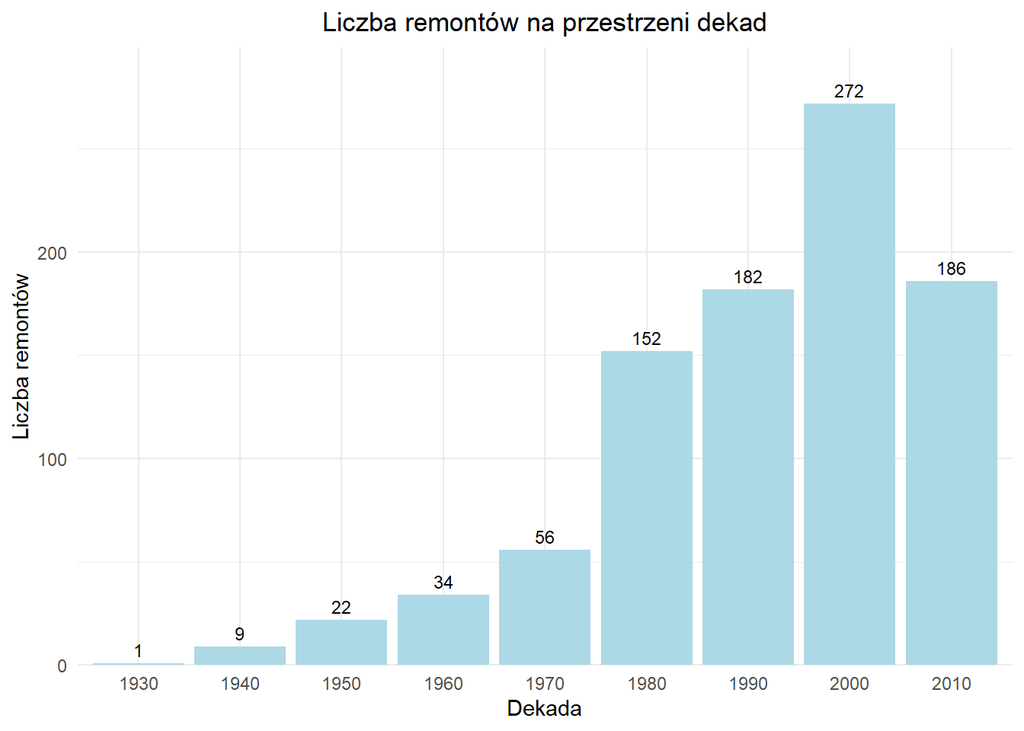

```r
# Tu umieść kod do wygenerowania odpowiedzi do zadania.

df_5 <- df %>%
  filter(yr_renovated != 0) %>%
  mutate(decade = floor(yr_renovated/10) * 10) %>%
  group_by(decade) %>%
  ggplot(aes(x = as.factor(decade))) +
  geom_bar(fill = "lightblue") +
  labs(title = "Liczba remontów na przestrzeni dekad",
       x = "Dekada", y = "Liczba remontów") +
  geom_text(stat = 'count', aes(label = after_stat(count)), vjust = -0.5, size = 3) +
  theme(plot.title = element_text(hjust = 0.5, size = 14)) +
  scale_y_continuous(expand = expansion(mult = c(0, 0.1))) +
  theme_minimal() +
  theme(plot.title = element_text(hjust = 0.5))


df_5
```

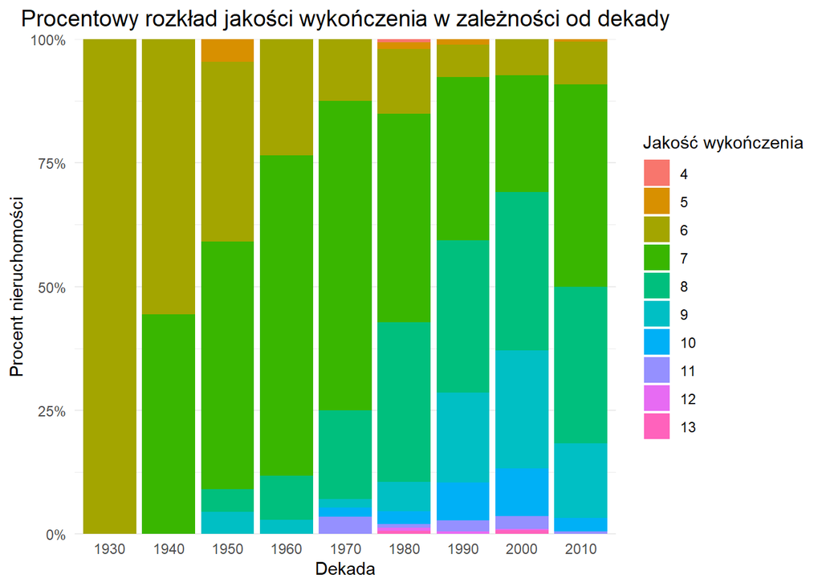

```r
df_5_1 <- df %>%
  filter(yr_renovated != 0) %>%
  mutate(decade = floor(yr_renovated/10) * 10) %>%
  group_by(decade,grade) %>%
  summarise(count = n()) %>%
  ungroup() %>%
  group_by(decade) %>%
  mutate(percentage = count / sum(count)) %>%
  mutate(percentage = count / sum(count)) %>%
  ggplot(aes(x = as.factor(decade), y = percentage, fill = as.factor(grade))) +
  geom_bar(stat = "identity", position = "stack") +
  labs(title = "Liczba remontów na przestrzeni dekad",
       x = "Dekada", y = "Liczba remontów")  +
  scale_y_continuous(labels = scales::percent_format(), expand = c(0,0)) +
  labs(
    title = "Procentowy rozkład jakości wykończenia w zależności od dekady",
    x = "Dekada",
    y = "Procent nieruchomości",
    fill = "Jakość wykończenia"
  ) +
  theme_minimal() +
  theme(plot.title = element_text(hjust = 0.5, size = 14))

df_5_1
```

**Komentarz:** Najwięcej remontów przeprowadzono w 2000 dekadzie, było ich 272. Na podstawie drugiego wykresu można zauważyć, że procent nieruchomości dla każdej wartości miary jakości i wykończenia nieruchomości nie do końca jest porównywalny. Widzimy, że z każdą kolejną dekadą malał udział jakości 6. Wartości poniżej 6 pojawiają się rzadko. Można powiedzieć, że jakość wykończenia rośnie z każdą kolejną dekadą, jedynie w 2010 dekadzie ta tendencja nie jest zachowana. Być może ma to związek ze spadkiem liczby remontów.

## Zadanie 6

Jak prezentuje się wartość minimalna, średnia i maksymalna ceny nieruchmości w podziele na rok budowy nieruchomości.

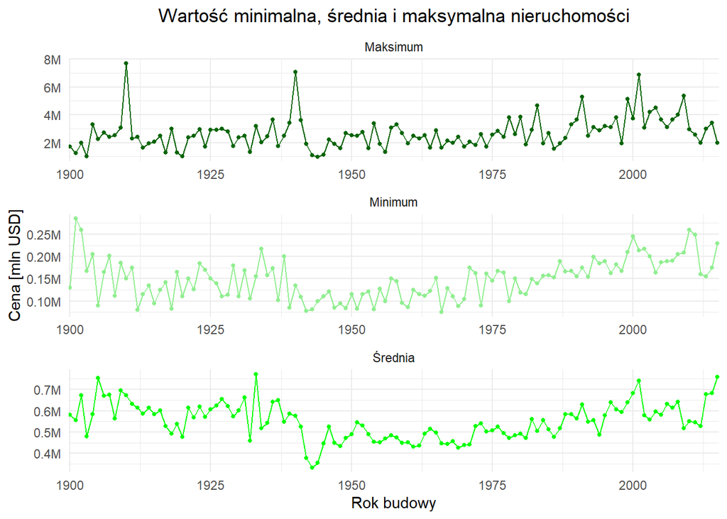

```r
# Tu umieść kod do wygenerowania odpowiedzi do zadania.

df_6 <- df %>%
  group_by(yr_built) %>%
  summarise(Minimum = min(price), Maksimum = max(price), Średnia = mean(price)) %>%
  tidyr::pivot_longer(cols = c(Minimum, Maksimum, Średnia),names_to = "type", values_to = "value")

df_6_1 <- ggplot(df_6, aes(x = yr_built, color = type)) +
  geom_point(aes(y = value), size = 1) +
  geom_line(aes(y = value)) +
  facet_wrap(~type, ncol = 1, scales = "free") +
  labs(title = "Wartość minimalna, średnia i maksymalna nieruchomości",
       x = "Rok budowy", y = "Cena [mln USD]") +
  scale_color_manual(values = c("Minimum" = "lightgreen", "Średnia" = "green", "Maksimum" = "darkgreen")) +
  theme_minimal() +
  theme(plot.title = element_text(hjust = 0.5), legend.position = "none") +
  scale_x_continuous(expand = c(0,0.25)) +
  scale_y_continuous(labels = scales::label_number(scale = 1e-6, suffix = "M"))

df_6_1
```

**Komentarz:** Największe różnice procentowe dotyczą wartości maksymalnych. Najbardziej zauważalne “skoki” na wykresie widać około roku 1910 i 1940. Duże wahania odnotowano także dla nieruchomości z roku około 2000. W okresach szczytowych najwyższa cena maksymalna osiąga 8 milionów USD. Ceny minimalne także ulegają zmianie. Wartości cen minimalnych są kilkadziesiąt razy mniejsze od cen maksymalnych. Najmniejsze różnice procentowe dotyczą wartości średnich. Najmniejsze średnie ceny przyjmowane były dla nieruchomości z roku około 1942. Nastąpił wtedy wyrażny spadek maksymalnej ceny. Po latach 70-tych ceny minimalne i średnie mają raczej tendencję wzrostową. Aby lepiej zauważyć różnice cen, rozbiłam wykres na 3 - osobny dla każdej z wartości - przy użyciu facet_wrap.